# Tentativo - MLR Exercises

Gianmaria Pizzo

# 1 Esercizio 1

I dati in grain.dat sono stati raccolti nel 2007 in uno studio sulla relazione tra la resa in termini di alcool nel processo di distillazione e l’azoto contenuto nel grano distillato. I dati sono stati raccolti in quattro diverse aree del Regno Unito.

```r
grains <-read.table("grains.dat")
```

Il dataset ha tre colonne:

- nitrogen, la percentuale di azoto (per kilogrammo),
- alcohol e la resa in alcool in Litri per Tonnellata,
- elocation indica il luogo in cui e stato coltivato il grano.

[Il dataset e stato reso disponibile da Julian Faraway.]

La relazione tra la resa in termini di alcool e l’azoto contenuto nel grano pu`o essere indagata con il seguente modello lineare:

$$alcohol_{i} = \alpha + \beta \text{
nitrogen}_{i} + \epsilon_{i}$$

## 1.1

Si produca un grafico dei dati. La relazione tra le variabili in esame appare lineare?

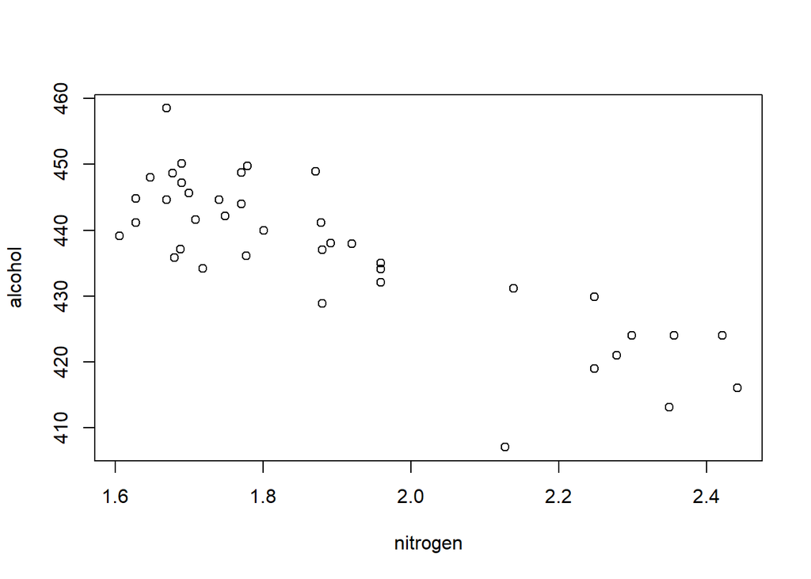

```r
fit_grain <- lm(alcohol~nitrogen, data = grains)
plot(alcohol~nitrogen, data = grains)
```

La relazione tra le variabili in esame apparte lineare, sebbene si evidenzino dei cluster, rispettivamente nei range (1.6,2.0) e (2.1, 2.5).

## 1.2

Si dia una stima puntuale (stimare i coefficienti) per $\alpha$ e $\beta$

$$\widehat{alcohol_{i}} = \hat{\beta_{0}}
+ \hat{\beta_{1}}nitrogen_{i} + \epsilon_{i} = 506.87 -37.034 \text{
}nitrogen_{i} + \epsilon_{i}$$

```r
fit_grain$coefficients
```

```
## (Intercept)    nitrogen
##   506.87058   -37.03356
```

## 1.3

Si dia una stima intervallare ad un livello di confidenza di 99% per $\alpha$ e $\beta$

```r
confint(fit_grain, level=0.99)
```

```
##                 0.5 %    99.5 %
## (Intercept) 485.61483 528.12633
## nitrogen    -48.14073 -25.92639
```

## 1.4

Quali sono le assunzioni necessarie per poter aver stime puntuali per i valori $\alpha$ e $\beta$?

Per poter ottenere delle stime puntuali di $\alpha$ e $\beta$, si assume che le osservazioni siano indipendenti fra loro ed identicamente distribuite con varianza costante e valore atteso che cambia approssimatamente linearmente con X.

Quali sono le assunzioni necessarie per poter ottenere delle stime intervallari per $\alpha$ e $\beta$?

Per poter ottenere delle stime intervallari per $\alpha$ e $\beta$ si assume **anche** che gli errori siano indipendenti e seguano una distribuzione normale a media zero e varianza costante (omoschedasticita’ degli errori) $\mathcal{N}(0, \sigma^2)$.

## 1.5

Si aggiunga la retta delle relazione stimata tra alcohol e nitrogen al grafico ottenuto al punto 1.

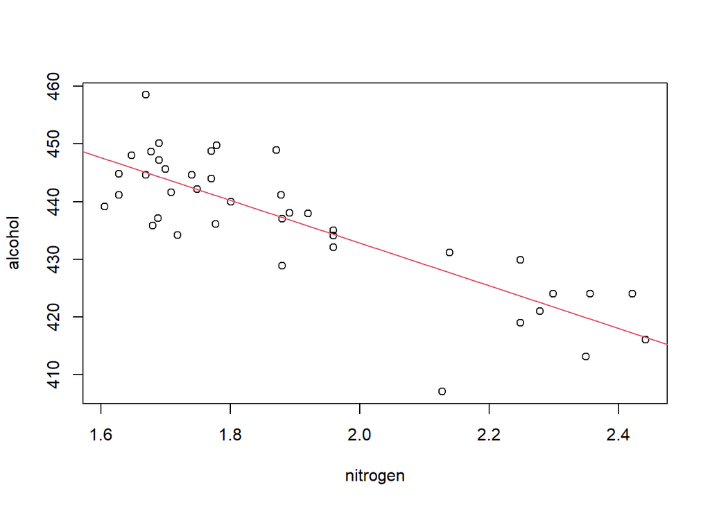

```r
plot(grains[,c("nitrogen","alcohol")])
# Or
# plot(alcohol~nitrogen, data = grains)

abline(fit_grain, col=2)
```

```r
# Or
#abline(a=coefficients(fit_grain)[1], b=coefficients(fit_grain)[2], col=2)
```

## 1.6

Il dataset contiene la variabile `location`.

```r
sort(unique(grains$location))
```

```
## [1] "Aberdeen"  "Berwicks"  "E.Lothian" "Norfolk"
```

Si scriva in forma estesa il modello che R stima quando si usa la funzione `lm(alcohol~location, data = grain)`.

$$alcohol_{i} = \alpha + \beta_{location}
+ \epsilon_{i}$$
con $\epsilon_{i} \stackrel{iid}\thicksim \mathcal{N}(0, \sigma^{2})$ varianza costante $\forall i=1,ldots,n$

Il modello stimerebbe 4 rette diverse (considerando che $beta_{0}$ e’ relativo al reference level rappresentato da `location = Aberdeen`):

- $[alcohol | location = Aberdeen] = \alpha + \epsilon_{i}$
- $[alcohol | location = Berwicks] = \alpha + \beta_{Berwicks}+ \epsilon_{i}$
- $[alcohol | location = E.Lothian] = \alpha + \beta_{E.Lothian} + \epsilon_{i}$
- $[alcohol | location = Norfolk] = \alpha + \beta_{Norfolk} + \epsilon_{i}$

## 1.7

E valida l’affermazione che la variabile location spiega una buona parte della variabilita della variabile alcohol?

```r
fit_grain2 <-lm(alcohol~location, data = grains)
summary(fit_grain2)$r.squared
```

```
## [1] 0.7281804
```

L’affermazione che la variabile location spiega una buona parte della variabilita della variabile alcohol, e’ valida poiche’ l’$R^2$ conferma che circa il 72.8 percento della varianza osservata nei dati e’ spiegata dalla relazione lineare tra alcoholo e la variabile location.

## 1.8

## 1.9

## 1.10

## 1.11

## 1.12

## 1.13

# 2 Esercizio 2

I dati nel file hotel.csv contengono informazioni sulla temperatura (X) e sul livello di occupazione di tre hotel (Y) in tre diverse citta.

## 2.1 1

## 2.2 2

## 2.3 3

## 2.4 4

# 3 Esercizio 3

# 4 Esercizio 4

# 5 Esercizio 5

# 6 Esercizio 6

# 7 Esercizio 7